# Mid-Term_STAT6443

Victoria Espinola

10/8/2020

```r
setwd("~/Desktop/STAT_6443")
library(DescTools); library(MASS); library(car)
bweight=read.csv("birthweight.csv", header=TRUE)
bweight$Black=as.factor(bweight$Black)
bweight$Married=as.factor(bweight$Married)
bweight$Boy=as.factor(bweight$Boy)
bweight$MomSmoke=as.factor(bweight$MomSmoke)
bweight$Ed=as.factor(bweight$Ed)
str(bweight)
```

```
## 'data.frame':    295 obs. of  6 variables:
##  $ Weight  : int  2891 3572 3827 4593 3940 2778 3544 3402 3147 3997 ...
##  $ Black   : Factor w/ 2 levels "0","1": 1 1 1 1 1 1 1 1 1 1 ...
##  $ Married : Factor w/ 2 levels "0","1": 2 2 2 2 1 2 2 2 1 2 ...
##  $ Boy     : Factor w/ 2 levels "0","1": 1 2 1 2 2 1 2 1 1 2 ...
##  $ MomSmoke: Factor w/ 2 levels "0","1": 1 1 1 1 2 1 1 1 1 1 ...
##  $ Ed      : Factor w/ 2 levels "0","1": 2 1 2 2 2 2 2 2 1 2 ...
```

#Exercise 1A: Boxplot for birth weight

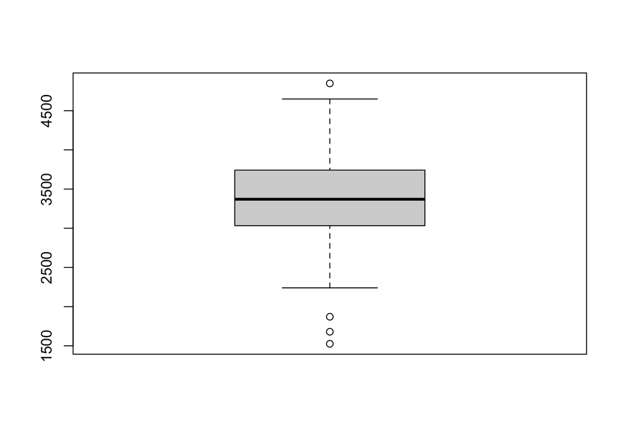

```r
boxplot(bweight$Weight)
```

##The data look normal from the boxplot output, but does show outlier points.

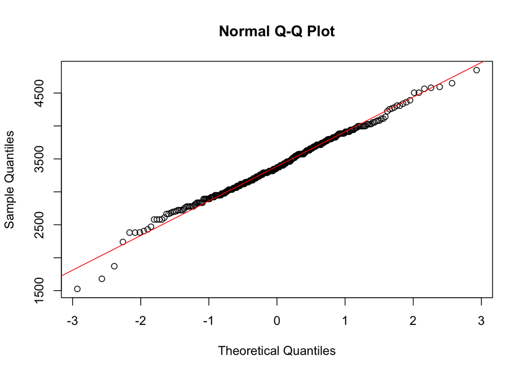

```r
qqnorm(bweight$Weight)
qqline(bweight$Weight, col="red")
```

```r
shapiro.test(bweight$Weight)
```

```
##
##  Shapiro-Wilk normality test
##
## data:  bweight$Weight
## W = 0.99206, p-value = 0.1153
```

##The normal qqplot and Shapiro-Wilk test both conclude that that normality assumption is reasonable for the weight variable.

#Exercise 1B: Boxplot of Weight by MomSmoke

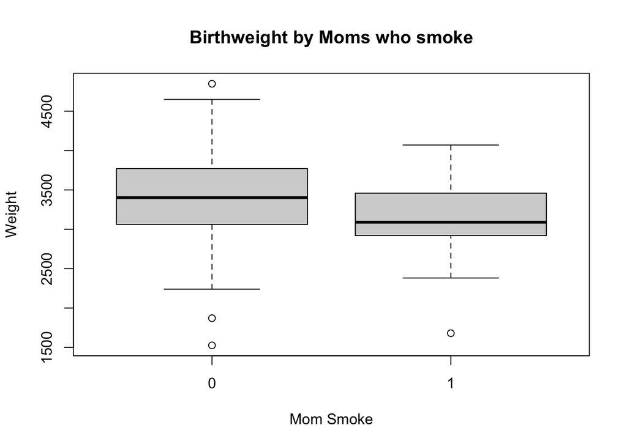

```r
boxplot(Weight~MomSmoke, data=bweight, main= "Birthweight by Moms who smoke", xlab="Mom Smoke", ylab="Weight")
```

##The mean birth weight is greater for babies whose mom did not smoke. The birth weight for mom’s who smoke is much closer together than for the weight of babies whose mom did not smoke. The range of the data for moms that did not smoke is greater than for moms who did smoke.

#Exercise 1C: Shapiro-Wilks Test by level of MomSmoke

```r
shapiro.test(bweight[bweight$MomSmoke=='0', "Weight"])
```

```
##
##  Shapiro-Wilk normality test
##
## data:  bweight[bweight$MomSmoke == "0", "Weight"]
## W = 0.99362, p-value = 0.3549
```

```r
shapiro.test(bweight[bweight$MomSmoke=='1', "Weight"])
```

```
##
##  Shapiro-Wilk normality test
##
## data:  bweight[bweight$MomSmoke == "1", "Weight"]
## W = 0.96299, p-value = 0.2
```

##For each level of MomSmoke the normality assumption is reasonable since both p-values are greater than 0.05.

#Exercise 2: Hypothesis Test

```r
t.test(bweight$Weight~bweight$MomSmoke)
```

```
##
##  Welch Two Sample t-test
##
## data:  bweight$Weight by bweight$MomSmoke
## t = 3.1562, df = 54.877, p-value = 0.002595
## alternative hypothesis: true difference in means is not equal to 0
## 95 percent confidence interval:
##   94.91074 425.12344
## sample estimates:
## mean in group 0 mean in group 1
##        3422.724        3162.707
```

##The null hypothesis is there is not difference in the mean birthweights for moms who do not smoke compared to moms who do smoke. The alternative hypothesis is that there is a difference in the mean birthweights for moms who do not smoke compared to moms who do smoke. According to the two-sample t-test, the p-value is 0.002595 which is less than our significance level of 0.05, so we reject the null hypothesis and conclude that there is a difference in birthweight for moms who do not smoke to those that do smoke.

#Exercise 3: One-Way ANOVA

```r
bw.aov<- aov(Weight~MomSmoke, data=bweight)
summary(bw.aov)
```

```
##              Df   Sum Sq Mean Sq F value  Pr(>F)
## MomSmoke      1  2386708 2386708   9.431 0.00233 **
## Residuals   293 74151291  253076
## ---
## Signif. codes:  0 '***' 0.001 '**' 0.01 '*' 0.05 '.' 0.1 ' ' 1
```

#3A: Homogeneity of variance assumption

```r
leveneTest(Weight~MomSmoke, data=bweight)
```

```
## Levene's Test for Homogeneity of Variance (center = median)
##        Df F value Pr(>F)
## group   1  0.6767 0.4114
##       293
```

##Since the p-value is greater than 0.05, then the assumption of homogeneity is valid. Since the data shows equal variance, it is ok to perform ANOVA test.

#Exercise 3B: Post-HOC Test

```r
TukeyHSD(bw.aov)
```

```
##   Tukey multiple comparisons of means
##     95% family-wise confidence level
##
## Fit: aov(formula = Weight ~ MomSmoke, data = bweight)
##
## $MomSmoke
##          diff       lwr       upr     p adj
## 1-0 -260.0171 -426.6549 -93.37931 0.0023339
```

##The null hypothesis is that there is no difference between the birthweights for moms who do not smoke and moms who do smoke. Since the Tukey post-hoc test provides a p-value less than 0.05, we reject the null hypothesis and conclude that one group has a different birthweight. This conclusion supports the conclusion made in Exercise 2.

#Exercise 4: ANOVA with Black, Married, Boy, MomSmoke, and Ed variabales.

```r
full= aov(Weight ~ Black + Married +Boy+ MomSmoke+ Ed, data=bweight)
#summary(full, type=3)
```

```r
back1= aov(Weight ~ Black + Married+ Boy+ MomSmoke, data=bweight)
#summary(back1, type=3)
```

```r
back2= aov(Weight ~ Black + Married + MomSmoke, data=bweight)
#summary(back2, type=3)
```

```r
back3= aov(Weight ~ Black +  MomSmoke, data=bweight)
#summary(back3, type=3)
```

##Exercise 4A: After running the full model, the least significant varabiable is Ed since it has the largest p-value. ##After running the model without Ed, the least significant variable is Boy since it has the largest p-value. ##After running the model without Boy, the least significant variable is Married since it has the largest p-value. ##After running the model without Married, both variables ‘Black’ and ‘MomSmoke’ are less than 0.5, so the model should include ‘Black’ and ‘MomSmoke’.

```r
final_with_interaction= aov(Weight ~ Black + MomSmoke + Black * MomSmoke, data=bweight)
#summary (final_with_interaction, type=3)
```

##Exercise 4B: The final model includes ‘Black’ and ‘MomSmoke’. The interaction effect will not be included because the p-value is greater than 0.05.

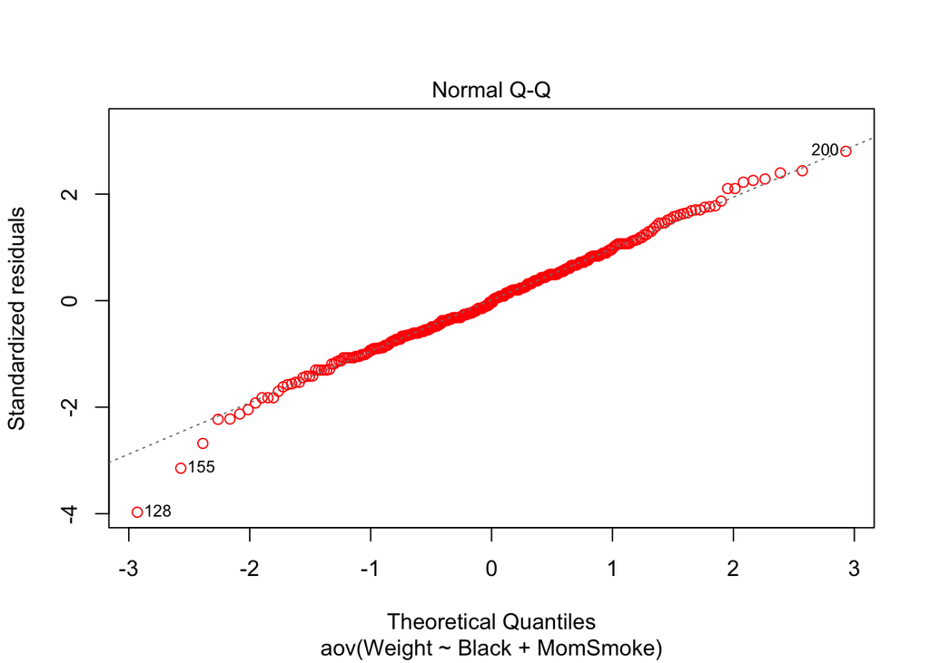

```r
plot(back3,2, col="red")
```

```r
linearmodel <- lm(Weight~ Black + MomSmoke, data=bweight)
summary(linearmodel)
```

```
##
## Call:
## lm(formula = Weight ~ Black + MomSmoke, data = bweight)
##
## Residuals:
##      Min       1Q   Median       3Q      Max
## -1947.38  -312.38   -14.38   325.62  1374.62
##
## Coefficients:
##             Estimate Std. Error t value Pr(>|t|)
## (Intercept)  3473.38      33.46 103.793  < 2e-16 ***
## Black1       -299.23      76.88  -3.892 0.000123 ***
## MomSmoke1    -266.88      82.72  -3.227 0.001395 **
## ---
## Signif. codes:  0 '***' 0.001 '**' 0.01 '*' 0.05 '.' 0.1 ' ' 1
##
## Residual standard error: 491.3 on 292 degrees of freedom
## Multiple R-squared:  0.07896,    Adjusted R-squared:  0.07266
## F-statistic: 12.52 on 2 and 292 DF,  p-value: 6.087e-06
```

```r
ScheffeTest(back3)
```

```
##
##   Posthoc multiple comparisons of means: Scheffe Test
##     95% family-wise confidence level
##
## $Black
##          diff    lwr.ci    upr.ci  pval
## 1-0 -293.9412 -483.0575 -104.8249 8e-04 ***
##
## $MomSmoke
##         diff    lwr.ci    upr.ci   pval
## 1-0 -266.763 -470.2261 -63.29987 0.0060 **
##
## ---
## Signif. codes:  0 '***' 0.001 '**' 0.01 '*' 0.05 '.' 0.1 ' ' 1
```

##Exercise 4C: Based on the Normal-QQ plot the data is normal. The amount of variation that can be explained by the model is 7.89%, which was calculated by using a linear model and obtaining the R-squared value. Based on the Scheffe Test, the mean birth weight of a non-black baby will be greater than a black baby and the mean birth weight of a baby whose mom did not smoke will be greater than a baby whose mom did smoke.